# Question

Mariana quiere calcular la cantidad de leche que cabe en el cilindro interno pero solamente cuenta con las medidas de las dimensiones que muestra la figura.

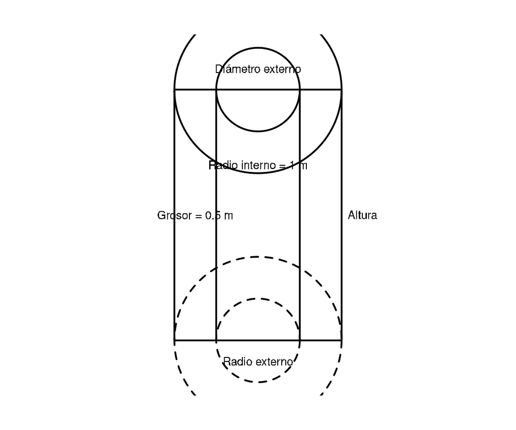

¿Qué medida le falta a Mariana para hallar la cantidad deseada?

## Answerlist

- Perímetro del cilindro
- Radio externo
- Diámetro externo
- Altura del cilindro

# Solution

Para resolver este problema, debemos analizar qué información necesitamos para calcular el volumen del cilindro interno, que determinará la cantidad de leche que puede contener.

El volumen de un cilindro se calcula con la fórmula: $V = \pi \cdot r^2 \cdot h$

Donde: - $r$ es el radio del cilindro - $h$ es la altura del cilindro

Por lo tanto, a Mariana le falta conocer la altura del cilindro para poder calcular la cantidad de leche que puede contener el cilindro interno.

## Answerlist

- Este es incorrecto. Conocer el perímetro del cilindro no es suficiente para calcular el volumen, ya tenemos esta información o no es necesaria
- Este es incorrecto. Conocer el radio externo no es suficiente para calcular el volumen, ya tenemos esta información o no es necesaria
- Este es incorrecto. Conocer la diámetro externo no es suficiente para calcular el volumen, ya tenemos esta información o no es necesaria
- Este es correcto. Para calcular el volumen del cilindro interno necesitamos conocer su altura del cilindro

# Meta-information

exname: Cilindro_Hueco_Volumen extype: schoice exsolution: 0001 exshuffle: TRUE